# Prediction of Benign and Malignant Breast Cancer

Harika Panuganty

4/3/2021

Introduction This dataset is publicly available on Kaggle (https://www.kaggle.com/uciml/breast-cancer-wisconsin-data) and looks at the physical features of a breast mass from digitized images from a file needle aspirate biopsy.

Breast cancer is the second leading cause of cancer death in women, with over 250,000 affected in 2018. Misdiagnoses of benign and malignant tumors can be detrimental towards treatment efforts as treatment options differ greatly between the two. This dataset consists of biopsies from breast cancer patients in Wisconsin and the database is UCI’s Machine Learning Repository.

The goal of this project is to determine whether a breast mass tumor is malignant or benign based on several different physical factors.

Project Methodology: In addition to predicting the classification of breast tumor, we wanted to find the most effective variable in determining malignancy or benignity of the tumor. This is how we did it: - Utilized two predictive modelling techniques: logistic regression (baseline) and neural networks We settled on 4 logistic regression models and 4 neural networks testing the different classes: All variables, Mean Variables, Worst variables + SE variables

Our model parameters were: Logistic Regression Train-test split: 70:30 Neural Networks Number = 3; 3 resampling iterations Grid size 2-50 with 1 layer in between Decay rate = 5e-4

Below chunk of code consists of: Data cleaning, doing 70-30 split, running logistic regression against ALL variables (mean + se + worst) and performing prediction on test dataset

```r
rm(list=ls())
library(plyr)
library(dplyr)
library(pROC)
library(caret)
```

```r
library(nnet)
library(ggplot2)
library(randomForest)
bcdata <- read.csv("~/Desktop/data.csv", header = TRUE)

#data cleaning
bc_data <- within(bcdata, rm(X)) #removed random X column in dataset
#summary(bc_data)

#as.factor diagnosis to determine if its a binary variable
bc_data$diagnosis <- as.factor(bc_data$diagnosis)

#we need as.factor to create as.integer
bc_data$diagnosis <- as.integer(bc_data$diagnosis == "M")

#as.factor to change the binary variable
bc_data$diagnosis <- as.factor(bc_data$diagnosis)
#summary(bc_data)

set.seed(345)
#to create a 70-30 split
bc_data_split <- createDataPartition(bc_data$diagnosis, p=.7, list = FALSE, times=1)

head(bc_data_split) #to double check
```

```
##      Resample1
## [1,]         2
## [2,]         3
## [3,]         4
## [4,]         6
## [5,]         7
## [6,]         9
```

```r
#Split data into test and train
bc_data.train <- bc_data[bc_data_split,]
bc_data.test <- bc_data[-bc_data_split,]

#Logistic regression on train dataset against all variables
bc_data.train.log <- glm(diagnosis~., data=bc_data.train, family="binomial")
#Perform prediction on test dataset
bc_data.test$pred_diagnosis <- predict.glm(bc_data.train.log, newdata = bc_data.test, type="response")

#First create a prediction object
pred <- roc(response = bc_data.test$diagnosis, predictor = bc_data.test$pred_diagnosis, direction = "<")

#Get AUC performance = 0.936953
auc_perf <- auc(pred)
cat("AUC: ", auc_perf, "\n")
```

```
## AUC:  0.9430352
```

```r
#AUC 95% CI = 0.8977693 0.936953 0.9761367
ci_auc_perf <- ci.auc(pred)
cat("95% CI: ", ci_auc_perf, "\n")
```

```
## 95% CI:  0.9056792 0.9430352 0.9803911
```

Below chunk of code consists of: Logistic regression on ALL MEAN variables and performing test prediction on dataset

```r
#Using dataset with all means
#Logistic regression on train dataset against mean variables

bc_data.train.log.mean <- glm(diagnosis~ radius_mean+texture_mean+ perimeter_mean+area_mean+smoothness_mean+compactness_mean+concavity_mean+ concave.points_mean+symmetry_mean+fractal_dimension_mean, data=bc_data.train, family="binomial")
#Perform prediction on test dataset
bc_data.test$pred_diagnosis.mean <- predict.glm(bc_data.train.log.mean, newdata = bc_data.test, type="response")

#First create a prediction object
pred.mean <- roc(response = bc_data.test$diagnosis, predictor = bc_data.test$pred_diagnosis.mean, direction = "<")

#Get AUC performance
auc_perf.mean <- auc(pred.mean)
cat("AUC: ", auc_perf.mean, "\n")
```

```
## AUC:  0.987984
```

```r
#AUC 95% CI
ci_auc_perf.mean <- ci.auc(pred.mean)
cat("95% CI: ", ci_auc_perf.mean, "\n")
```

```
## 95% CI:  0.9750928 0.987984 1
```

Below chunk of code consists of: Logistic regression on ALL WORST variables and performing test prediction on dataset

```r
#Using dataset with all worst
#Logistic regression on train dataset against worst variables

bc_data.train.log.worst <- glm(diagnosis~ radius_worst+texture_worst+ perimeter_worst+area_worst+smoothness_worst+compactness_worst+concavity_worst+ concave.points_worst+symmetry_worst+fractal_dimension_worst, data=bc_data.train, family="binomial")
#Perform prediction on test dataset
bc_data.test$pred_diagnosis.worst <- predict.glm(bc_data.train.log.worst, newdata = bc_data.test, type="response")

#First create a prediction object
pred.worst <- roc(response = bc_data.test$diagnosis, predictor = bc_data.test$pred_diagnosis.worst, direction = "<")

#Get AUC performance
auc_perf.worst <- auc(pred.worst)
cat("AUC: ", auc_perf.worst, "\n")
```

```
## AUC:  0.9820501
```

```r
#AUC 95% CI
ci_auc_perf.worst <- ci.auc(pred.worst)
cat("95% CI: ", ci_auc_perf.worst, "\n")
```

```
## 95% CI:  0.9569198 0.9820501 1
```

Below chunk of code consists of: Logistic regression on ALL MEAN + SE variables and performing test prediction on dataset

```r
#Using dataset with means + se
#Logistic regression on train dataset against mean + se variables
bc_data.train.log.mean.se <- glm(diagnosis~ radius_mean+texture_mean+ perimeter_mean+area_mean+smoothness_mean+compactness_mean+concavity_mean+ concave.points_mean+symmetry_mean+fractal_dimension_mean+radius_se+texture_se+ perimeter_se+area_se+smoothness_se+compactness_se+concavity_se+ concave.points_se+symmetry_se+fractal_dimension_se, data=bc_data.train, family="binomial")
#Perform prediction on test dataset
bc_data.test$pred_diagnosis.mean.se <- predict.glm(bc_data.train.log.mean.se, newdata = bc_data.test, type="response")

#First create a prediction object
pred.mean.se <- roc(response = bc_data.test$diagnosis, predictor = bc_data.test$pred_diagnosis.mean.se, direction = "<")

#Get AUC performance
auc_perf.mean.se <- auc(pred.mean.se)
cat("AUC: ", auc_perf.mean.se, "\n")
```

```
## AUC:  0.9890224
```

```r
#AUC 95% CI
ci_auc_perf.mean.se <- ci.auc(pred.mean.se)
cat("95% CI: ", ci_auc_perf.mean.se, "\n")
```

```
## 95% CI:  0.9747571 0.9890224 1
```

Below chunk of code consists of: Creating forestplot for logistic regression The AUC’s and 95% CI for each of the classes are very narrow and it is difficult to identify the best AUC value and the tightest 95% CI, so below is a forest plot to clearly show and compare between the classes. Taking a look at this plot, we can note that class All mean + SE has the best AUC and a tight 95% CI therefore being the best logistic regression model out of the 4.

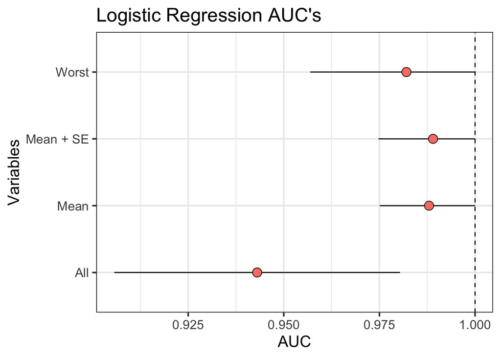

```r
library(ggplot2)
forest.plot <- read.csv("~/Desktop/forestplot.csv", header = TRUE)
# reverses the factor level ordering for labels after coord_flip()
#df$label <- factor(df$label, levels=rev(df$label))


fp.log <- ggplot(data=forest.plot, aes(x=Logistic.AUC, y=AUC, ymin=AUC_left, ymax=AUC_right)) +
        geom_pointrange() +
        geom_hline(yintercept=1, lty=2) +
        coord_flip() +  # flip coordinates (puts labels on y axis)
        xlab("Variables") + ylab("AUC") +
        theme_bw(base_size = 16) + ggtitle("Logistic Regression AUC's") + geom_point(shape=21, fill="salmon", color = "black", size=4)
print(fp.log)
```